# Unit #3 Code

The goals of this assignment are to help you (1) calculate expectations of random variables using R, (2) simulate probabilistic processes, and (3) estimate probabilities and other quantities through numerical (computer) simulation. Such simulations can be useful. We can use simulations to help confirm that we've calculated a probability "by hand" correctly, or to estimate other quantities, like areas/integrals!

## Problem #1

**1.(a) Write a function to calculate the expected value of a binomial random variable, using the definition of expectation.**

```r
e = function(n,p){
    x = 0:n
    e = sum(x*dbinom(x,n,p))
    return (e)
}
e(100,1/4)
```

25

**1.(b) Store m = 10,000 binomial random numbers in a vector x. Each entry of x should represent the number of tails in 50 flips of a biased coin (P(H) = 0.75).**

```r
n = 50;  p = 3/4
x = rbinom(10000, n, p)
head(x)
```

1. 37

2. 35

3. 41

4. 42

5. 38

6. 37

**(c) Calculate the (sample) mean of x. Then, use the formula for the mean of a binomial, and the function above, to calculuate the mean the random variable X = # of heads in 50 flips of a biased coin (P(H) = 0.75). What do you notice? Do these answers match?**

```r
mean(x)
n*p
```

37.5186

37.5

I notice that calculating the sample mean is approximately the same as calculating the theorical mean from the equation $n*p$

## Problem #2

In class, we calculated some integrals analytically. Let's do them numerically here.

```r
integrand = function(x, lambda){
    integrand = x*dexp(x,lambda)
    return(integrand)
}
e = function(l){
    e = integrate(integrand, lower = 0, upper = Inf, lambda = l)
    return (e)
}
e(4)
```

```
0.25 with absolute error < 3.2e-05
```

We also worked with the pdf $f(x) = \frac{3}{4}(1-x^2)$ on $-1\le x \le 1$ (zero elsewhere).

**2.(b) Find $E(X^3)$.**

```
0.0625 with absolute error < 6.9e-16
```

```
-0.0625 with absolute error < 6.9e-16
```

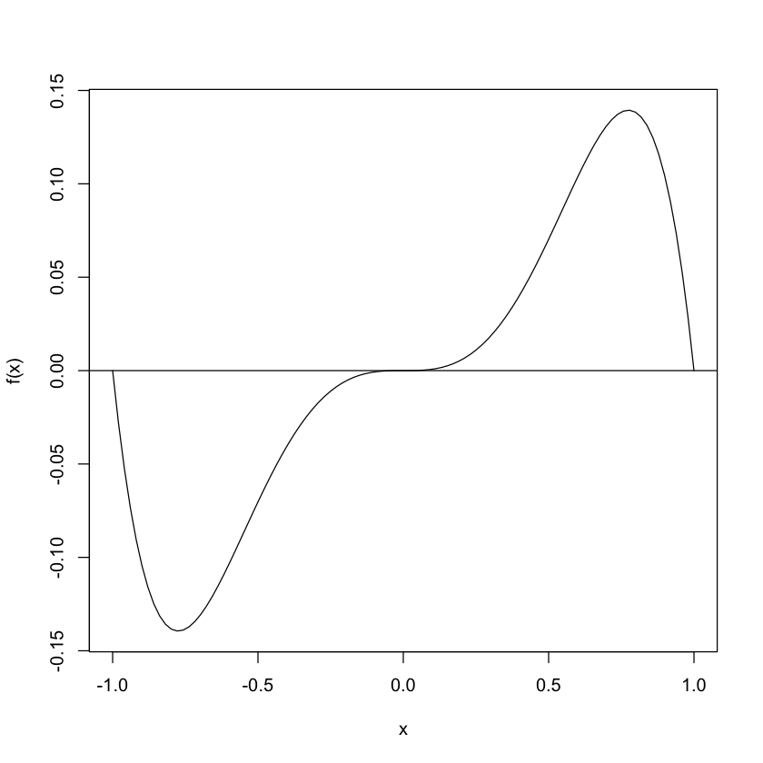

```r
n = 100; x = seq(-1,1,length.out = 100)

f = function(x){
    f = x^3*3/4*(1-x^2)
    return(f)
}
plot(x,f(x), type = 'l')
abline(0,0)

integrate(f, 0,1)
integrate(f,-1,0)
```

**2.(c) Estimate $E(X^3)$ using Monte Carlo integration.**

```r
m = 5000; y = runif(m,0,1); x = runif(m,0,1);
above = sum(y < f(x))/m

y = runif(m,-1,0); x = runif(m,-1,0);
below = sum(y > f(x))/m
above-below
```

-0.005

## Problem #3

In class, we emphasized that variables can be uncorrelated but dependent. Let's look at an example of this.

**3.(a) Generate $n = 5000$ random variables from a $U(-1,1)$ distribution. Store these values in `x`. Then, create a variable `y` such that $y = x^2$. Plot `x` and `y` and compute the (sample) correlation coefficient using `cor()`. What do you notice?**

0.0122858731625521

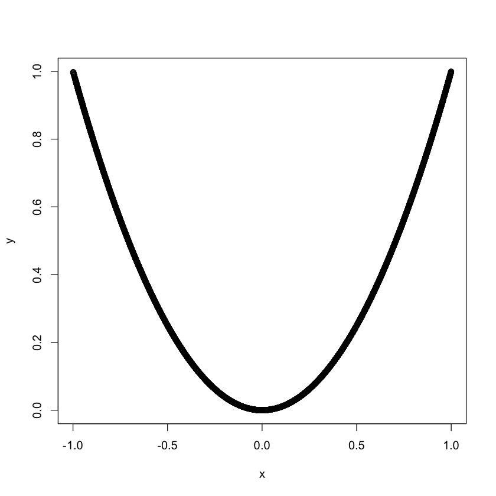

```r
n = 5000
x = runif(n,-1,1); y = x^2 #+ rnorm(n, 0,0.01)
plot(x,y)
cor(x,y)
```

We have a parabola and the correlation coefficient is approximately zero.

**3.(b) Now add various degrees of "noise" to `y`, by adding random normal numbers to the `y` equation. Use `rnorm(n,0,b)`, where `b` is set to values like `0.01`, `0.1`, and `1`. What do you notice about the plot and corresponding correlation coefficient?**

0.0121304948674335

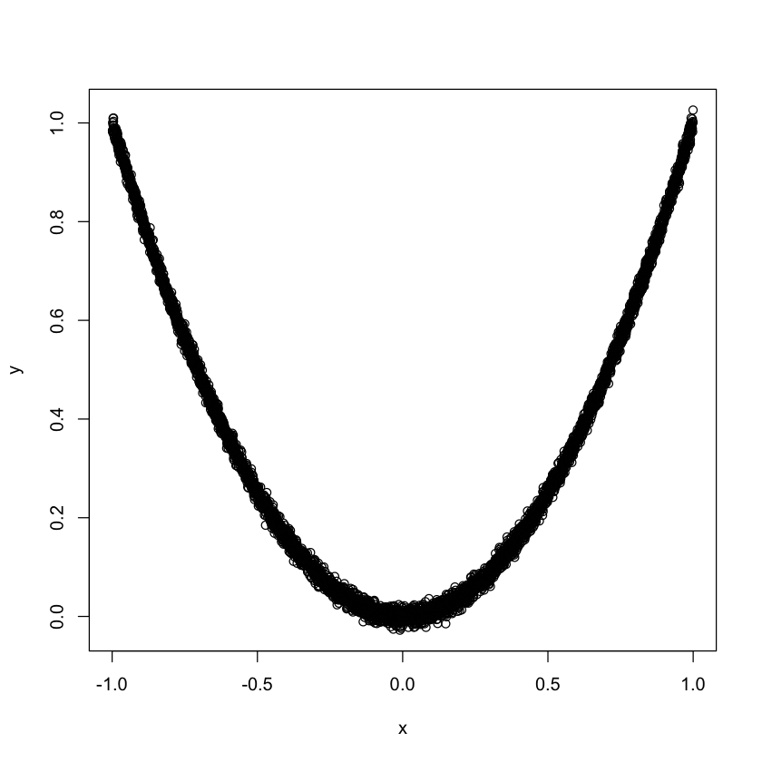

```r
y = x^2 + rnorm(n, 0, 0.01)
plot(x,y)
cor(x,y)
```

0.00443398041674803

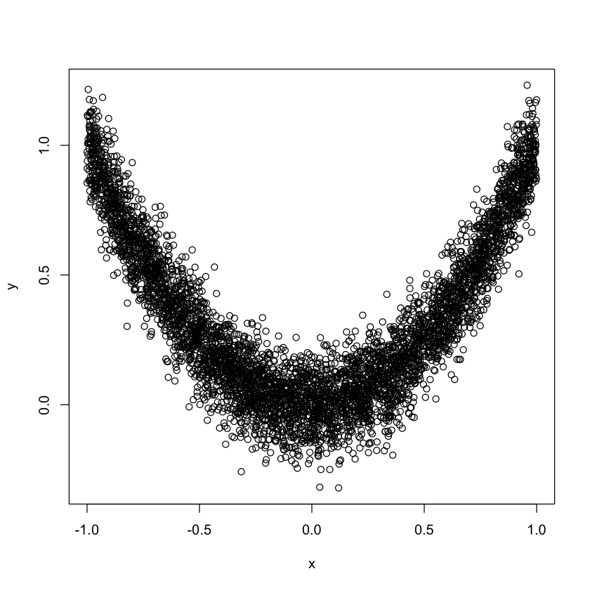

```r
y = x^2 + rnorm(n, 0, 0.1)
plot(x,y)
cor(x,y)
```

0.00918970690864526

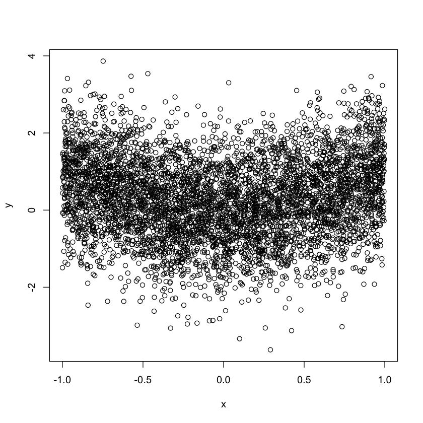

```r
y = x^2 + rnorm(n, 0,1)
plot(x,y)
cor(x,y)
```